# Dimensionality reduction techniques

In this chapter the purpose is to get familiar with some Dimensionality Reduction Techniques including Principal Component Analysis (PCA) and Multiple Correspondece Analysis (MCA).

Principal Component Analysis is a way of identifying patterns in data, and expressing the data in such a way as to highlight their similarities and differences. After founding the patterns PCA has the tools of compressing the data by reducing the number of dimensions, without much loss of information. [Additional info of PCA](https://en.wikipedia.org/wiki/Principal_component_analysis)

Multiple Correspondence Analysis is used for the same purposes as PCA but it can be utilized if the data contains categorical variables. [Additional info of MCA](https://en.wikipedia.org/wiki/Multiple_correspondence_analysis)

## Brief description of the dataset

In this chapter I will be working with the **Data of Human Development approach** adopted from [United Nations Development programme, UNDP](http://hdr.undp.org/en/humandev). This programme has explored human development around the world with specific indices in each year since 1990, [Country List in 2015](http://hdr.undp.org/en/countries). The specified indices are:

1. the Human Development Index, HDI
2. the Inequality-Adjusted Human Development Index, IHDI
3. the Gender Development Index, GDI
4. the Gender Inequality Index, GII
5. the Multidimensional Poverty Index, MPI

**I’m going to work with HDI and GII indices by combining the datasets and using specific variables including:**

1. country - technically a rowname
2. SFM_edu = SFedu / SMedu, where
   - SFedu - Females, Population with at least some secondary education (% ages 25 and older)
   - SMedu - Males, Population with at least some secondary education (% ages 25 and older)
3. FMlabour = Flabour / Mlabour, where
   - Mlabour - Males, Labour force participation rate (% ages 15 and older
   - Flabour - Females, Labour force participation rate (% ages 15 and older)
4. Eedu - Expected years of schooling per country
5. Elife - Expected life years at birth per country
6. GNIpc - Gross national income per capita per country in PPP, (https://en.wikipedia.org/wiki/Purchasing_power_parity)
7. mort_ratio - Maternal mortality ratio (deaths per 100,000 live births)
8. ad_birth - Adolescent birth rate (births per 1,000 women ages 15-19)
9. seats - Share of seats in parliament (% held by women)

**Note 1**, SFM_edu is a ratio of education where values less than 1 are signifying that males are more educated than females and values greater than 1 are implying that females are more educated than men.

**Note 2**, FMlabour is a ratio of labour force participation where values less than 1 are signifying that males are more participated than females and values greater than 1 are implying that females are more participated than men.

**Note 3**, variables from the Human Development Index data are Eedu, Elife and GNIpc while the other variables are from the Gender Inequality Index data.

For additional information you can find [here](http://hdr.undp.org/en/composite/HDI) the Human Development Index data and its components.

For additional information you can find [here](http://hdr.undp.org/en/composite/GII) the Gender Inequality Index data and its components.

**COMBINED DATASET**

You can find the combined dataset from my GutHub respitory: https://github.com/8475394/IODS-project/blob/master/data/human_1.txt

```r
library(tidyr); library(readr)
human_own <- read.table(file.path("C:/Users/heidi/Documents/YLIOPISTO/TILASTOTIEDE/INTRODUCTION TO OPEN DATA SCIENCE/IODS-project/data", "human_1.txt"), header = TRUE)
```

**STRUCTURE OF THE HUMAN DATASET**

From the structure table you can notice that there are 155 observation and 8 variables. Note that the country is actaully a rowname and it doesn’t appear to variable list.

```r
str(human_own)
```

```
## 'data.frame':    155 obs. of  8 variables:
##  $ SFM_edu   : num  1.007 0.997 0.983 0.989 0.969 ...
##  $ FMlabour  : num  0.891 0.819 0.825 0.884 0.829 ...
##  $ Eedu      : num  17.5 20.2 15.8 18.7 17.9 16.5 18.6 16.5 15.9 19.2 ...
##  $ Elife     : num  81.6 82.4 83 80.2 81.6 80.9 80.9 79.1 82 81.8 ...
##  $ GNIpc     : int  64992 42261 56431 44025 45435 43919 39568 52947 42155 32689 ...
##  $ mort_ratio: int  4 6 6 5 6 7 9 28 11 8 ...
##  $ ad_birth  : num  7.8 12.1 1.9 5.1 6.2 3.8 8.2 31 14.5 25.3 ...
##  $ seats     : num  39.6 30.5 28.5 38 36.9 36.9 19.9 19.4 28.2 31.4 ...
```

## Summaries and graphs

In this section I’m going to explore the distributions of data variables even further. First I show you a summary table which contains the distributions of each variable where the variables are divided into quartiles including the minimum and maximum values.

After this I’ll show you a set of histograms and explore the potential relationhips between each variable.

**SUMMARY TABLE OF DATA VARIABLES**

You may see some intresting “phenomena” from the summary table. Both the ratio of education (SFM_edu) and labour force participation (FMlabour) suggest that males are more dominant in these fields. It seems that females are more equal in education than labour force participation. You can examine this visually from the histograms later in this chapter.

According to the [Technical notes](http://hdr.undp.org/sites/default/files/hdr2015_technical_notes.pdf) of the Human Development indices, the scale of expected years of schooling per country (Eedu) varies between 0 and 18 where the latter is equivalent to achieving a master’s degree in most countries. However you can see that the actual maximum of the schooling distribution is a bit over 20. If I understood right the range of 0-18 is used when counting the overall Human Development Index. Nevertheless I think the average of expected schooling years is quite good even though these values don’t tell us anything about specific countries.

I can’t help myself to wonder the minimum value of Expected life years at birth per country (Elife). 49 years seem so low even though the mean and median values are much greater.

I think the distribution of Gross National Income per capita PPP emphasizes the huge distinctions between countries and of their wealth. Note that GNI per capita in PPP measures purchasing power parity which is useful for making comparisons between countries, [PPP](https://en.wikipedia.org/wiki/Purchasing_power_parity). However, there is a but when measuring the Human Development Index. If you look at [the table of HDI](http://hdr.undp.org/en/composite/HDI) (as seen earlier), you can perceive that the GNI is not necessary the most critical measure in terms of well-being. For example the GNI of Montenegro is lower than average but the Human Development Index is very high. Note also that this was kind of an additional information since the actual HD index is not a part of this examination.

Based on the technical notes the Maternal Mortality rate represent the maternal health, the higher the rate the poorer the maternal health. If you look at [the table of GII](http://hdr.undp.org/en/composite/GII) (as seen earlier), you can perceive that the maximum value of the maternal mortality among countries with very high human development is 69. This is just to give you some understanding of this scale.

Adolescent birth rate represents the rate of births per 1000 women between ages between 15 and 19. I think this scale varies also a lot. However the distribution is skewed to the right (positive skewness) suggesting that there are more lower than higher values in this scale.

The distribution of seats represents the share (%) of seats in parliament held by women in each country. Here you can see for example that it is not common to have more females than males in parliaments as the median and mean values are both close to 20 %. Also there are just few countries where the women are in majority.

```r
library(knitr)
kable(summary(human_own), format = "pandoc", digits = 2,  align="l")
```

|  | SFM_edu | FMlabour | Eedu | Elife | GNIpc | mort_ratio | ad_birth | seats |
| --- | --- | --- | --- | --- | --- | --- | --- | --- |
|  | Min. :0.1717 | Min. :0.1857 | Min. : 5.40 | Min. :49.00 | Min. : 581 | Min. : 1.0 | Min. : 0.60 | Min. : 0.00 |
|  | 1st Qu.:0.7264 | 1st Qu.:0.5984 | 1st Qu.:11.25 | 1st Qu.:66.30 | 1st Qu.: 4198 | 1st Qu.: 11.5 | 1st Qu.: 12.65 | 1st Qu.:12.40 |
|  | Median :0.9375 | Median :0.7535 | Median :13.50 | Median :74.20 | Median : 12040 | Median : 49.0 | Median : 33.60 | Median :19.30 |
|  | Mean :0.8529 | Mean :0.7074 | Mean :13.18 | Mean :71.65 | Mean : 17628 | Mean : 149.1 | Mean : 47.16 | Mean :20.91 |
|  | 3rd Qu.:0.9968 | 3rd Qu.:0.8535 | 3rd Qu.:15.20 | 3rd Qu.:77.25 | 3rd Qu.: 24512 | 3rd Qu.: 190.0 | 3rd Qu.: 71.95 | 3rd Qu.:27.95 |
|  | Max. :1.4967 | Max. :1.0380 | Max. :20.20 | Max. :83.50 | Max. :123124 | Max. :1100.0 | Max. :204.80 | Max. :57.50 |

**HISTOGRAMS OF EDUCATION, LABOUR FORCE, YEARS OF SCHOOLING AND LIFESPAN**

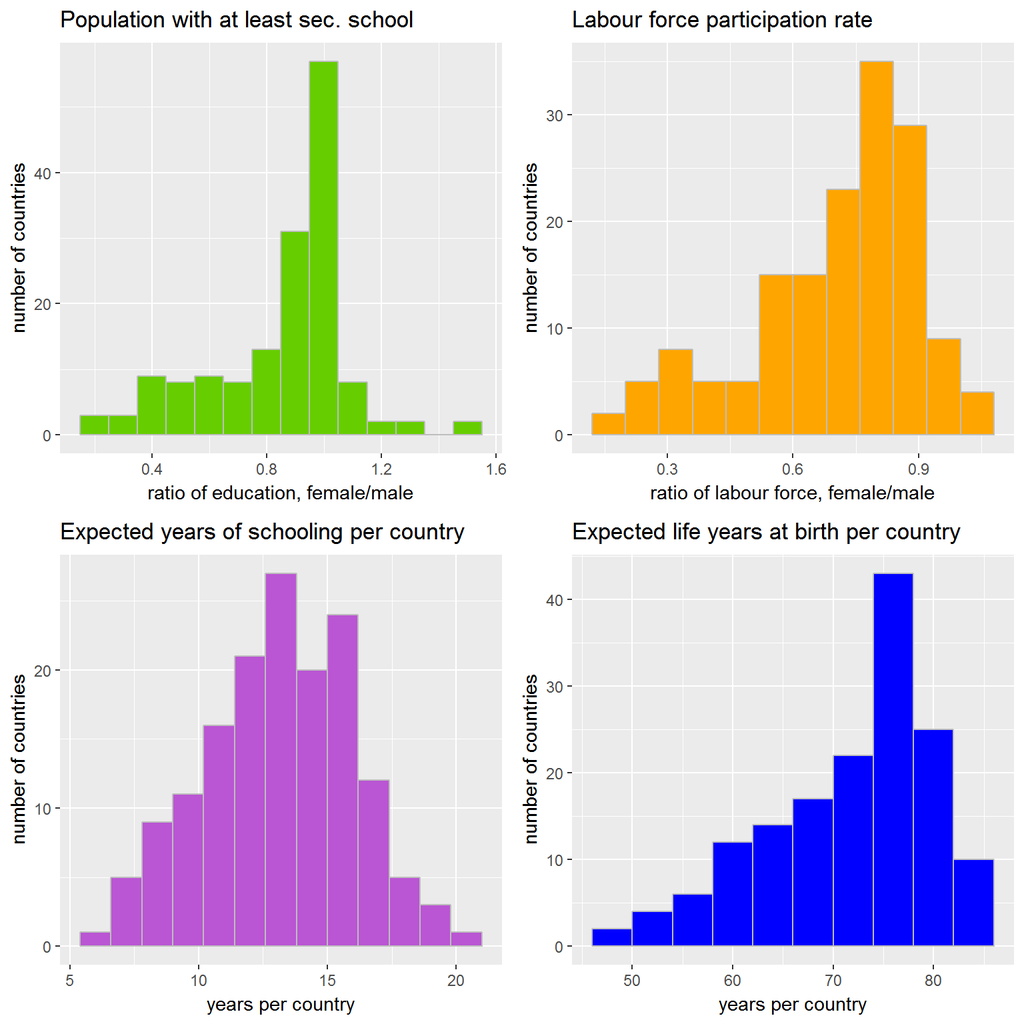

```r
library(ggplot2); library(gridExtra);library(dygraphs)

# INITIALIZING THE PLOTS

h1 <- qplot(human_own$SFM_edu, geom = "histogram", binwidth = 0.1, main = "Population with at least sec. school", xlab = "ratio of education, female/male", ylab = "number of countries", col = I("grey"), fill = I("chartreuse3"))

h2 <- qplot(human_own$FMlabour, geom = "histogram", binwidth = 0.08, main = "Labour force participation rate", xlab = "ratio of labour force, female/male", ylab = "number of countries", col = I("grey"), fill = I("orange"))

h3 <- qplot(human_own$Eedu, geom = "histogram", binwidth = 1.2, main = "Expected years of schooling per country", xlab = "years per country", ylab = "number of countries", col = I("grey"), fill = I("mediumorchid"))

h4 <- qplot(human_own$Elife, geom = "histogram", binwidth = 4, main = "Expected life years at birth per country", xlab = "years per country", ylab = "number of countries", col = I("grey"), fill = I("blue"))

# Combining the plots using the function grid.arrange()

grid.arrange(h1, h2, h3, h4, ncol=2, nrow =2)
```

**HISTOGRAMS OF GNI, MATERNAL MORTALITY, ADOLESCENT BIRTH RATE AND SHARE OF SEATS**

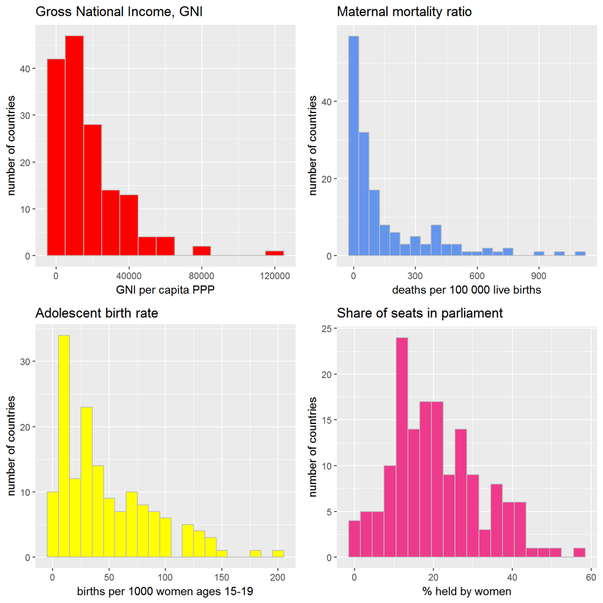

```r
library(ggplot2); library(gridExtra); library(dygraphs)

# INITIALIZING THE PLOTS

h5 <- qplot(human_own$GNIpc, geom = "histogram", binwidth = 10000, main = "Gross National Income, GNI", xlab = "GNI per capita PPP", ylab = "number of countries", col = I("grey"), fill = I("red"))

h6 <- qplot(human_own$mort_ratio, geom = "histogram", binwidth = 50, main = "Maternal mortality ratio", xlab = "deaths per 100 000 live births", ylab = "number of countries", col = I("grey"), fill = I("cornflowerblue"))

h7 <- qplot(human_own$ad_birth, geom = "histogram", binwidth = 10, main = "Adolescent birth rate", xlab = "births per 1000 women ages 15-19", ylab = "number of countries", col = I("grey"), fill = I("yellow"))

h8 <- qplot(human_own$seats, geom = "histogram", binwidth = 3, main = "Share of seats in parliament", xlab = "% held by women", ylab = "number of countries", col = I("grey"), fill = I("violetred2"))

# Combining the plots using the function grid.arrange()

grid.arrange(h5, h6, h7, h8, ncol=2, nrow =2)
```

**INITIAL RESULTS OF THE RELATIONSHIPS**

Here you can have an initial look at the relationships between human data variables. I added a regression line into each scatterplot to better perceive the direction of the relationships.

**NOTE**, According to James, Witten, Hastie & Tibshirani (2013, 375) these two-dimenional scatterplots are most likely not so informative when we want to explore the total information of the data. This is the case especially if we have a lot of variables. Futhermore these two-dimensional plots contain just a small fraction of the total information present in the dataset.

However I will explore also the correlations between the variables before continuing the dimensionality reduction part. Correlation matrix and plot are seen after the initial results.

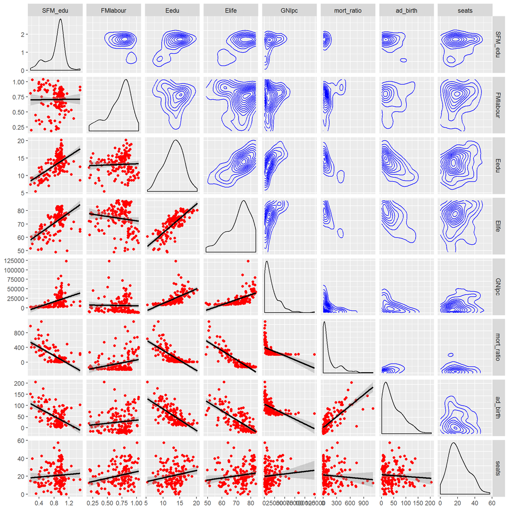

```r
library(GGally); library(ggplot2)
g = ggpairs(human_own, lower = list(continuous = wrap("smooth", method = "lm", color="red")), upper = list(continuous = wrap("density", color = "blue")))
g
```

**CORRELATION MATRIX BETWEEN DATA VARIABLES**

Here I’m going to explore more closely the linear relationships between variables to get a better understanding of the data. You can see the correlation coefficients of each pair from table below. It is interesting that there is almost zero correlation between SFM_edu (ratio of education, F/M) and FMlabour (ratio of labour force, F/M). Initially I thought that there may be a linear relationship between these variables at least to some extent. However, the SFM_Edu has some other interesting relationships for example with Maternal mortality ratio (mort_ratio) and Adolescent birth rate (ad_birth). These relationships are negative, suggesting that when the ratio of Female Education is high the ratios of Maternal mortality and Adolecent’s birth are respectively low. You can perceive the same logic also between Expected years of schooling per country (Eedu) and the mort_ratio/ad_birth as well as between Expected life years at birth per country (Elife) and the mort_ratio/ad_birth.

Interestingly the Gross National Income per capita (GNIpc) has a positive relationship with Expected years of schooling per country (Eedu) and Expected life years at birth per country (Elife). It may be a natural consequence that if a country is wealthy they can invest more for education. But I think there might be some other components affecting to the lifespan of population even though there is a positive correlation between GNI and life years.

If you look at the “Seats” column (or row), i.e. Share of seats in parliament (% held by women), there are no high correlation values while it has relationships with FMlabour and Eedu in to some extent. The former may suggest that when the ratio of female labour force participation is high the number of seats in parliament (held by women) can also be high and vice versa. The latter can imply that when the Expected years of schooling per country is high the number of seats in parliament (held by women) can also be high. Here I can imagine that if there are high amount of schooling years in some country there would be also more educated women among the population to be voted to the parliament. Note that the latter point of view was just “an educated guess”!

After the correlation matrix you can see a more visual “correlation matrix”.

```r
library(tidyverse); library(knitr)
cor_matrix <- cor(human_own) %>% round(digits = 2)
kable(cor_matrix, format = "pandoc", digits = 2,  align="c")
```

|  | SFM_edu | FMlabour | Eedu | Elife | GNIpc | mort_ratio | ad_birth | seats |
| --- | --- | --- | --- | --- | --- | --- | --- | --- |
| SFM_edu | 1.00 | 0.01 | 0.59 | 0.58 | 0.43 | -0.66 | -0.53 | 0.08 |
| FMlabour | 0.01 | 1.00 | 0.05 | -0.14 | -0.02 | 0.24 | 0.12 | 0.25 |
| Eedu | 0.59 | 0.05 | 1.00 | 0.79 | 0.62 | -0.74 | -0.70 | 0.21 |
| Elife | 0.58 | -0.14 | 0.79 | 1.00 | 0.63 | -0.86 | -0.73 | 0.17 |
| GNIpc | 0.43 | -0.02 | 0.62 | 0.63 | 1.00 | -0.50 | -0.56 | 0.09 |
| mort_ratio | -0.66 | 0.24 | -0.74 | -0.86 | -0.50 | 1.00 | 0.76 | -0.09 |
| ad_birth | -0.53 | 0.12 | -0.70 | -0.73 | -0.56 | 0.76 | 1.00 | -0.07 |
| seats | 0.08 | 0.25 | 0.21 | 0.17 | 0.09 | -0.09 | -0.07 | 1.00 |

**PLOTTING THE CORRELATION MATRIX**

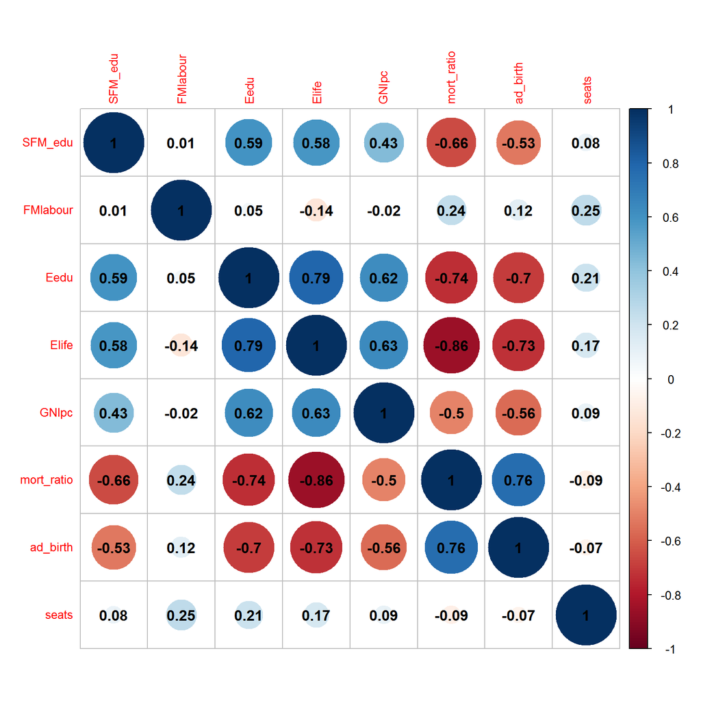

```r
library(corrplot)
corrplot(cor_matrix, method = "circle", tl.cex = 0.8, addCoef.col = "black")
```

## Principal Component Analysis, PCA, with the NON-standardized data

When we have a large set of correlated variables, Principal Component Analysis allows us to summarize this set with a smaller number of representative variables that collectively explain most of the variability in our dataset. PCA is an unsupervised learning algorithm which means that there is no outcome to be predicted but instead it tries to find patterns in the data. This can be done by data visualizing as seen in this and will be seen in the next chapter.

First I’m going to perform principal component analysis (PCA) without standardizing the Human data. Note that the PCA is performed again within the next chapter but with standardized dataset. Thus the purpose is to perceive and interpret if there are any differences between these methods or models and my guess is that the actual purpose is to show and justify why the data has to be standardized.

**SUMMARY TABLE OF NON-STANDARDIZED DATA**

Here you can see the same summary table of Human dataset as seen in the beginning of this chapter. It is shown again for the practical reasons to better compare the results between PCAs with non-standardized and standardized datasets.

```r
library(knitr)
kable(summary(human_own), format = "pandoc", digits = 2,  align="l")
```

|  | SFM_edu | FMlabour | Eedu | Elife | GNIpc | mort_ratio | ad_birth | seats |
| --- | --- | --- | --- | --- | --- | --- | --- | --- |
|  | Min. :0.1717 | Min. :0.1857 | Min. : 5.40 | Min. :49.00 | Min. : 581 | Min. : 1.0 | Min. : 0.60 | Min. : 0.00 |
|  | 1st Qu.:0.7264 | 1st Qu.:0.5984 | 1st Qu.:11.25 | 1st Qu.:66.30 | 1st Qu.: 4198 | 1st Qu.: 11.5 | 1st Qu.: 12.65 | 1st Qu.:12.40 |
|  | Median :0.9375 | Median :0.7535 | Median :13.50 | Median :74.20 | Median : 12040 | Median : 49.0 | Median : 33.60 | Median :19.30 |
|  | Mean :0.8529 | Mean :0.7074 | Mean :13.18 | Mean :71.65 | Mean : 17628 | Mean : 149.1 | Mean : 47.16 | Mean :20.91 |
|  | 3rd Qu.:0.9968 | 3rd Qu.:0.8535 | 3rd Qu.:15.20 | 3rd Qu.:77.25 | 3rd Qu.: 24512 | 3rd Qu.: 190.0 | 3rd Qu.: 71.95 | 3rd Qu.:27.95 |
|  | Max. :1.4967 | Max. :1.0380 | Max. :20.20 | Max. :83.50 | Max. :123124 | Max. :1100.0 | Max. :204.80 | Max. :57.50 |

**PERFORMING PCA WITH SINGULAR VALUE DECOMPOSITION METHOD**

There are two slightly different methods to perform the PCA: the Eigenvalue Decomposition and the Singular Value Decomposition. According to our instructions in DataCamp the latter is preferred.

From the tables and biplot below you can see the results of Principal Component Analysis with non-standardized Human data. The results are trying to say that there is only one principal component in the Human data. Since PCA is based on capturing the biggest variation of the dataset, you can perceive that the method captures only the variance of Gross National Income (GNI). This is because the GNI has a largest range of its scale and the other variables are not comparable with this scale. Thus, we can have such a misleading results if we forget to standardize our data.

```r
# Performing the PCA with Singular Value Decomposition (SVD) method
pca_human1 <- prcomp(human_own)
s1 <- summary(pca_human1)
s1
```

```
## Importance of components:
##                              PC1      PC2   PC3   PC4   PC5   PC6    PC7
## Standard deviation     1.854e+04 185.5219 25.19 11.45 3.766 1.566 0.1912
## Proportion of Variance 9.999e-01   0.0001  0.00  0.00 0.000 0.000 0.0000
## Cumulative Proportion  9.999e-01   1.0000  1.00  1.00 1.000 1.000 1.0000
##                           PC8
## Standard deviation     0.1591
## Proportion of Variance 0.0000
## Cumulative Proportion  1.0000
```

```r
# rounded percetanges of variance captured by each PCA
pca_pr1 <- round(100*s1$importance[2, ], digits = 1)
print(pca_pr1)
```

```
## PC1 PC2 PC3 PC4 PC5 PC6 PC7 PC8
## 100   0   0   0   0   0   0   0
```

```r
# creating object pc_lab to be used as axis labels
pc_lab1 <- paste0(names(pca_pr1), " (", pca_pr1, "%)")
pc_lab1
```

```
## [1] "PC1 (100%)" "PC2 (0%)"   "PC3 (0%)"   "PC4 (0%)"   "PC5 (0%)"
## [6] "PC6 (0%)"   "PC7 (0%)"   "PC8 (0%)"
```

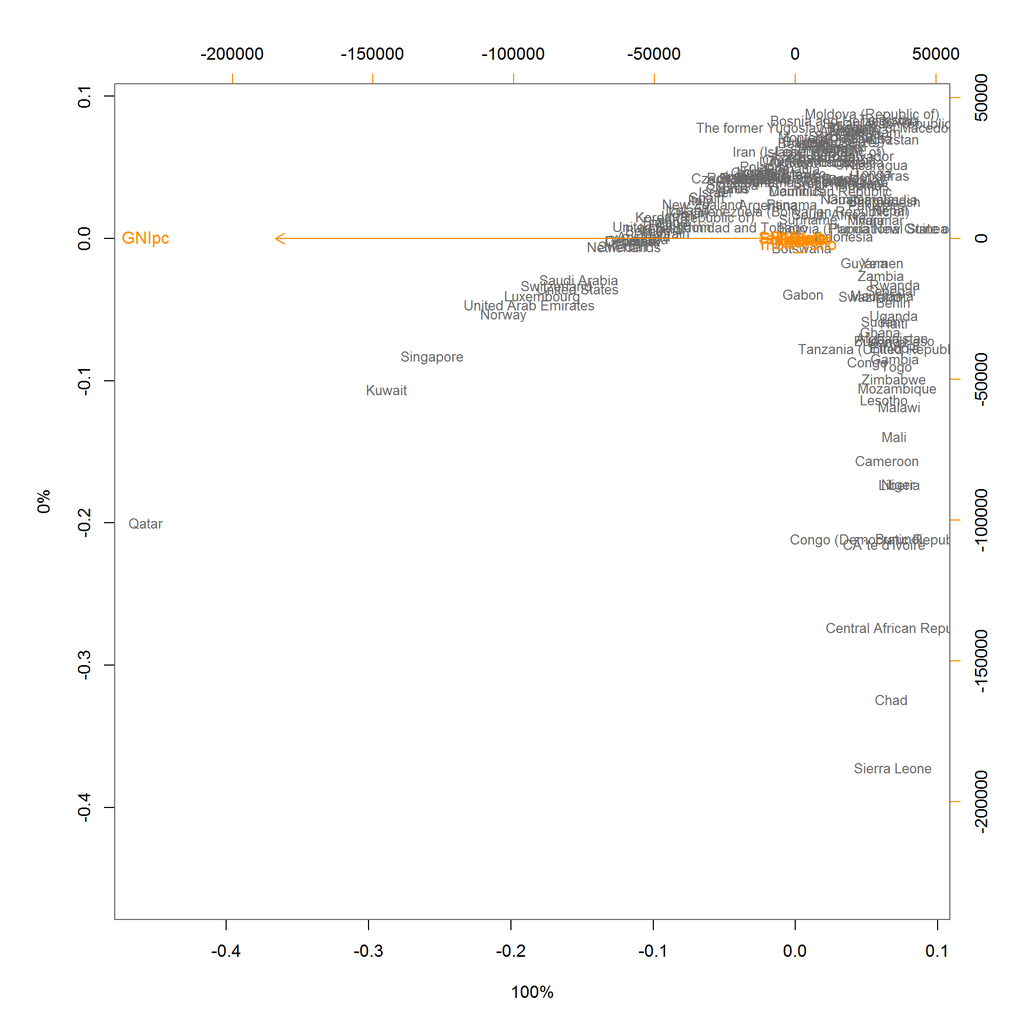

```r
# drawing the biplot with captions
biplot(pca_human1, cex = c(0.8, 1), col = c("dimgrey", "darkorange"), xlab = "100%", ylab = "0%")
```

## Repeating the PCA with standardized data

Here I provide some additional information of PCA. The purpose of PCA is to find a low-dimensional representation of a dataset that contains as much as possible of the variation. It is very important to realize that not all of these dimensions, i.e. principal components, are equally interesting. Furthermore it is known that the first principal component captures the most of the variance in the **normalized** (standardized) dataset. The second principal component captures the maximal variance of the dataset that are uncorrelated with the first component and so on.(James, Witten, Hastie & Tibshirani, 2013, 375-376.)

**SUMMARY TABLE OF THE STANDARDIZED HUMAN DATA**

As you can see from the table below, the distributions of the variables changed after stardardizing the dataset. Now the mean of every variable is zero and the observations varies on both sides of zero. This means that the different distributions are now more comparable for the further purposes.

```r
# Standardizing the Human data
std_human <- scale(human_own)

library(knitr)
kable(summary(std_human), format = "pandoc", digits = 2,  align="l")
```

|  | SFM_edu | FMlabour | Eedu | Elife | GNIpc | mort_ratio | ad_birth | seats |
| --- | --- | --- | --- | --- | --- | --- | --- | --- |
|  | Min. :-2.8189 | Min. :-2.6247 | Min. :-2.7378 | Min. :-2.7188 | Min. :-0.9193 | Min. :-0.6992 | Min. :-1.1325 | Min. :-1.8203 |
|  | 1st Qu.:-0.5233 | 1st Qu.:-0.5484 | 1st Qu.:-0.6782 | 1st Qu.:-0.6425 | 1st Qu.:-0.7243 | 1st Qu.:-0.6496 | 1st Qu.:-0.8394 | 1st Qu.:-0.7409 |
|  | Median : 0.3503 | Median : 0.2316 | Median : 0.1140 | Median : 0.3056 | Median :-0.3013 | Median :-0.4726 | Median :-0.3298 | Median :-0.1403 |
|  | Mean : 0.0000 | Mean : 0.0000 | Mean : 0.0000 | Mean : 0.0000 | Mean : 0.0000 | Mean : 0.0000 | Mean : 0.0000 | Mean : 0.0000 |
|  | 3rd Qu.: 0.5958 | 3rd Qu.: 0.7350 | 3rd Qu.: 0.7126 | 3rd Qu.: 0.6717 | 3rd Qu.: 0.3712 | 3rd Qu.: 0.1932 | 3rd Qu.: 0.6030 | 3rd Qu.: 0.6127 |
|  | Max. : 2.6646 | Max. : 1.6632 | Max. : 2.4730 | Max. : 1.4218 | Max. : 5.6890 | Max. : 4.4899 | Max. : 3.8344 | Max. : 3.1850 |

**PERFORMING PCA WITH SINGULAR VALUE DECOMPOSITION METHOD**

The tables and biplot below tell a huge different story about principal components in the Human data compared with earlier findings. The tables suggest that the first principal component has captured 53.6% of the total variance from the Human data. The second component has captured 16.2% and so on. As you can see, these shares are diminishing quite fast implying that the first principal components actually captures the most of the variance.

```r
# Performing the PCA with Singular Value Decomposition (SVD) method
pca_human2 <- prcomp(std_human)
s2 <- summary(pca_human2)
s2
```

```
## Importance of components:
##                           PC1    PC2     PC3     PC4     PC5     PC6
## Standard deviation     2.0708 1.1397 0.87505 0.77886 0.66196 0.53631
## Proportion of Variance 0.5361 0.1624 0.09571 0.07583 0.05477 0.03595
## Cumulative Proportion  0.5361 0.6984 0.79413 0.86996 0.92473 0.96069
##                            PC7     PC8
## Standard deviation     0.45900 0.32224
## Proportion of Variance 0.02634 0.01298
## Cumulative Proportion  0.98702 1.00000
```

```r
# rounded percetanges of variance captured by each PCA
pca_pr2 <- round(100*s2$importance[2, ], digits = 1)
print(pca_pr2)
```

```
##  PC1  PC2  PC3  PC4  PC5  PC6  PC7  PC8
## 53.6 16.2  9.6  7.6  5.5  3.6  2.6  1.3
```

**ILLUSTRATING AND INTERPRETING THE RESULTS WITH A BIPLOT**

The pricipal components are illustrated in the biplot below. Just to remind that there are 155 countries and 8 variables thus the principal component score vectors have lenght n=155, and the pricipal component loading vectors have lenght p=8. Figure below plots the first two pricipal components of the data and represents both the principal component scores and the loading vectors.

From the biplot we can see that the first principal component places approximately equal weight on mort_ratio and ad_birth corresponding to their high reciprocal and positive correlation. Accordingly The first pricipal component places approximately equal weight on SFM_edu, Eedu, Elife and GNIpc which also corresponds with the high positive correlations between each of these variables. Note that each of the former variables correlate negatively with each of the latter variables“. This means that these variables belong into the same principal component, i.e. representing the same phenomenon but from the opposite angles.

Now I have to think what could be the common nominator for all of the variables listed so far. I think I will call the first principal component as the **National well-being index** since the component consists features like level and lenght of education, the lifespan and the Gross National Income combined with maternal mortality ratio and adolescent’s birth rate. Let’s take some examples from the biplot. Countries like Qatar, Australia and Norway seem to have a high index of wellbeing since they have high negative scores on the first component, i.e. low scores in terms of mortality and adolescent’s birth rate and “high opposite scores”. Accordingly countries like Chad, Niger and Sierra Leone seem to have a low index of well-being since they have high positive scores on the first component, i.e. high scores in terms of mortality and adolescent’s birth rate and “low opposite scores”.

I think, in certain terms, I could compare the scale of the the first principal component to Osgood’s scale which attemps to measure some polarities or contrasts but usually with opposite adjectives. But if we wanted to combine the variable for example by summing, we could translate the scale direction of either set of variables.

Let’s take some examples from the biplot in terms of the second component. Countries like Iceland, Bolivia, Mozambique and especially the Rwanda have high positive scores on our “National Index of Equal Employment” while countries like Iran, Lebanon and Yemen have very low scores.

But since the biplot is a “fourfold table”, we can find more interpretations. We can start from the upper left corner where we can find Finland, earlier mentioned Iceland and Denmark, i.e. Scandinavia and some other European countries. These countries represent the ideal places considering both our indices, i.e. high in employment equality and well-being. Upper right corner has high in equality but low in well-being, e.g. Mozambigue. Lower right corner has low both in well-being and equality and there you can find for exmple Niger and Afghanistan. Finally we have lower left corner which represent countries with high in well-being but low with employment equality. There are countries like Qatar, Kuwait and Saudi-Arabia.

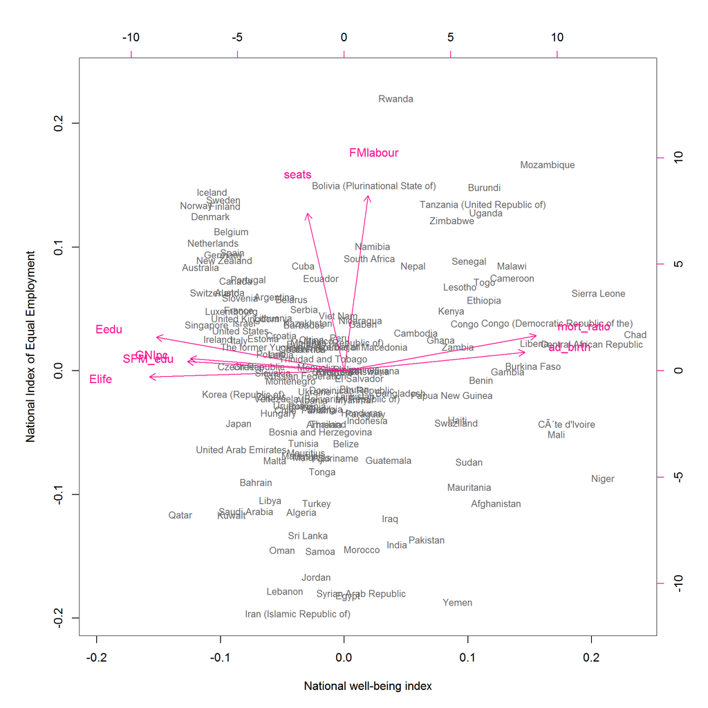

```r
# drawing the biplot again with captions

biplot(pca_human2, cex = c(0.8, 1), col = c("dimgrey", "deeppink"), xlab = "National well-being index", ylab = "National Index of Equal Employment")
```

## Multiple Correspondence Analysis, MCA

Here the purpose is to get familiar with Multiple Correspondece Analysis, MCA. It is a dimensions reducing method and it represents the data in 2- or 3-dimensional space. [Here](https://github.com/gabi493/ADEI/blob/master/Husson%20F.%20et%20al.%20-%20Exploratory%20Multivariate%20Analysis%20by%20Example%20-%20Using%20R%20-%202011.pdf) you can find additional information concerning the MCA.

For the purpose of Multiple Correspondence Analysis I have to download a new dataset since MCA can be utilized when the data contains categorical variables and my earlier dataset contained only continuous variables.

I’m going to download the **Tea dataset** from the **FactoMineR** packages.

**STRUCTURE OF THE TEA DATASET**

As you can imagine the data concern a questionnaire on tea consumption. There are 300 individuals who where asked how they drink tea, 18 questions. Then there are supplementary variables like age and sex. Note that the age is the only continuous variable in the dataset. 12 questions concern about individuals’ product perception and 4 guestions consis some personal details. You can see the whole structure from table below.

```r
library(FactoMineR) # https://cran.r-project.org/web/packages/FactoMineR/index.html
data("tea")
str(tea)
```

```
## 'data.frame':    300 obs. of  36 variables:
##  $ breakfast       : Factor w/ 2 levels "breakfast","Not.breakfast": 1 1 2 2 1 2 1 2 1 1 ...
##  $ tea.time        : Factor w/ 2 levels "Not.tea time",..: 1 1 2 1 1 1 2 2 2 1 ...
##  $ evening         : Factor w/ 2 levels "evening","Not.evening": 2 2 1 2 1 2 2 1 2 1 ...
##  $ lunch           : Factor w/ 2 levels "lunch","Not.lunch": 2 2 2 2 2 2 2 2 2 2 ...
##  $ dinner          : Factor w/ 2 levels "dinner","Not.dinner": 2 2 1 1 2 1 2 2 2 2 ...
##  $ always          : Factor w/ 2 levels "always","Not.always": 2 2 2 2 1 2 2 2 2 2 ...
##  $ home            : Factor w/ 2 levels "home","Not.home": 1 1 1 1 1 1 1 1 1 1 ...
##  $ work            : Factor w/ 2 levels "Not.work","work": 1 1 2 1 1 1 1 1 1 1 ...
##  $ tearoom         : Factor w/ 2 levels "Not.tearoom",..: 1 1 1 1 1 1 1 1 1 2 ...
##  $ friends         : Factor w/ 2 levels "friends","Not.friends": 2 2 1 2 2 2 1 2 2 2 ...
##  $ resto           : Factor w/ 2 levels "Not.resto","resto": 1 1 2 1 1 1 1 1 1 1 ...
##  $ pub             : Factor w/ 2 levels "Not.pub","pub": 1 1 1 1 1 1 1 1 1 1 ...
##  $ Tea             : Factor w/ 3 levels "black","Earl Grey",..: 1 1 2 2 2 2 2 1 2 1 ...
##  $ How             : Factor w/ 4 levels "alone","lemon",..: 1 3 1 1 1 1 1 3 3 1 ...
```

[output cut: 22 more lines]

**VARIABLES TO KEEP**

I’m going to reduce the number of variables and choose some specific active variables, including:

**The time of the day when the tea in drunk**

1. breakfast - Do you drink tea at breakfast (yes, no)?
2. evening - Do you drink tea in the evening (yes, no)?
3. lunch - Do you drink tea after lunch (yes, no)?
4. dinner - Do you drink tea after dinner (yes, no)?

**Tea-drinking behaviour**

5. Tea - What kind of tea do you drink the most (black tea, green team flavoured tea)?
6. How - How do you take your tea (nothing added, with lemon, with milk, other)?
7. sugar - Do you add sugar to your tea (yes, no)?
8. how - What kind of tea do you buy (tea bags, loose tea, both)?
9. where - Where do you buy your tea (in the supermarket, in specialist shops, both)?
10. price - What kind of tea do you buy (cheapest, supermarket brand, well-known brand, luxury, it varies, I don’t know)?

Additionally I’m going to call this new data as **my_tea**

```r
library(dplyr)

# identifying the columns to keep
keep_columns <- c("breakfast", "evening", "lunch", "dinner", "Tea", "How", "sugar", "how", "where", "price")

# selecting the columns
my_tea <- dplyr::select(tea, one_of(keep_columns))
```

**STRUCTURE OF MY_TEA DATASET**

```r
str(my_tea)
```

```
## 'data.frame':    300 obs. of  10 variables:
##  $ breakfast: Factor w/ 2 levels "breakfast","Not.breakfast": 1 1 2 2 1 2 1 2 1 1 ...
##  $ evening  : Factor w/ 2 levels "evening","Not.evening": 2 2 1 2 1 2 2 1 2 1 ...
##  $ lunch    : Factor w/ 2 levels "lunch","Not.lunch": 2 2 2 2 2 2 2 2 2 2 ...
##  $ dinner   : Factor w/ 2 levels "dinner","Not.dinner": 2 2 1 1 2 1 2 2 2 2 ...
##  $ Tea      : Factor w/ 3 levels "black","Earl Grey",..: 1 1 2 2 2 2 2 1 2 1 ...
##  $ How      : Factor w/ 4 levels "alone","lemon",..: 1 3 1 1 1 1 1 3 3 1 ...
##  $ sugar    : Factor w/ 2 levels "No.sugar","sugar": 2 1 1 2 1 1 1 1 1 1 ...
##  $ how      : Factor w/ 3 levels "tea bag","tea bag+unpackaged",..: 1 1 1 1 1 1 1 1 2 2 ...
##  $ where    : Factor w/ 3 levels "chain store",..: 1 1 1 1 1 1 1 1 2 2 ...
##  $ price    : Factor w/ 6 levels "p_branded","p_cheap",..: 4 6 6 6 6 3 6 6 5 5 ...
```

```r
head(my_tea)
```

```
##       breakfast     evening     lunch     dinner       Tea   How    sugar
## 1     breakfast Not.evening Not.lunch Not.dinner     black alone    sugar
## 2     breakfast Not.evening Not.lunch Not.dinner     black  milk No.sugar
## 3 Not.breakfast     evening Not.lunch     dinner Earl Grey alone No.sugar
## 4 Not.breakfast Not.evening Not.lunch     dinner Earl Grey alone    sugar
## 5     breakfast     evening Not.lunch Not.dinner Earl Grey alone No.sugar
## 6 Not.breakfast Not.evening Not.lunch     dinner Earl Grey alone No.sugar
##       how       where           price
## 1 tea bag chain store       p_unknown
## 2 tea bag chain store      p_variable
## 3 tea bag chain store      p_variable
## 4 tea bag chain store      p_variable
## 5 tea bag chain store      p_variable
## 6 tea bag chain store p_private label
```

**SUMMARY TABLE OF THE MY_TEA DATASET**

From the table below you can have closer look at the categories of the kept variables.

```r
summary(my_tea)
```

```
##          breakfast          evening          lunch            dinner
##  breakfast    :144   evening    :103   lunch    : 44   dinner    : 21
##  Not.breakfast:156   Not.evening:197   Not.lunch:256   Not.dinner:279
##
##
##
##
##         Tea         How           sugar                     how
##  black    : 74   alone:195   No.sugar:155   tea bag           :170
##  Earl Grey:193   lemon: 33   sugar   :145   tea bag+unpackaged: 94
##  green    : 33   milk : 63                  unpackaged        : 36
##                  other:  9
##
##
##                   where                 price
##  chain store         :192   p_branded      : 95
##  chain store+tea shop: 78   p_cheap        :  7
##  tea shop            : 30   p_private label: 21
##                             p_unknown      : 12
##                             p_upscale      : 53
##                             p_variable     :112
```

**VISUALIZING THE STRUCTURES OF DATASET**

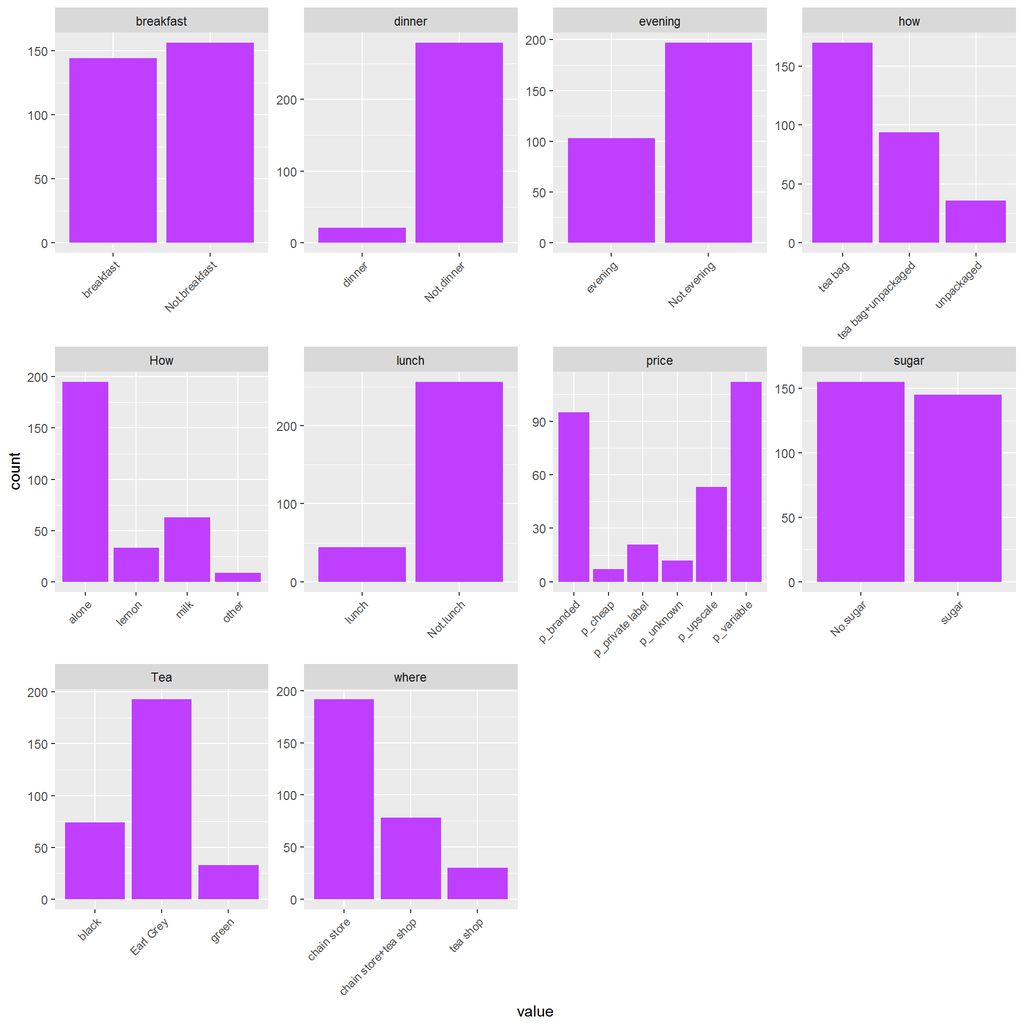

```r
library(tidyr); library(ggplot2)
gather(my_tea) %>% ggplot(aes(value)) + facet_wrap("key", scales = "free") + geom_bar(fill = "darkorchid1") + theme(axis.text.x = element_text(angle = 45, hjust = 1, size = 8))
```

**MULTIPLE CORRESPONDENCE ANALYSIS WITH MY_TEA DATASET**

This dataset could be studied according to the individuals, the variables and/or the categories. If studying the individuals, it mean to understand similarities between the individuals in terms of all variables. For example, two tea drinker are considered similar if they have answered the questions in the same way.

When studying variables and categories the aim is to summarise the relationships between all of the variables. Thus we are looking for a “synthetic” variables which sum up the information contained within a number of variables. This information can be studied in terms of the categories.

In MCA the main focus is on studying categories, as they represent both variables and a group of individuals.

Here the MCA is performed on the active individuals/variables.

```r
library(FactoMineR)

# Not yet plotting
mca <- MCA(my_tea, graph = FALSE)

print(mca) # Contains results as lists
```

```
## **Results of the Multiple Correspondence Analysis (MCA)**
## The analysis was performed on 300 individuals, described by 10 variables
## *The results are available in the following objects:
##
##    name              description
## 1  "$eig"            "eigenvalues"
## 2  "$var"            "results for the variables"
## 3  "$var$coord"      "coord. of the categories"
## 4  "$var$cos2"       "cos2 for the categories"
## 5  "$var$contrib"    "contributions of the categories"
## 6  "$var$v.test"     "v-test for the categories"
## 7  "$ind"            "results for the individuals"
## 8  "$ind$coord"      "coord. for the individuals"
## 9  "$ind$cos2"       "cos2 for the individuals"
## 10 "$ind$contrib"    "contributions of the individuals"
## 11 "$call"           "intermediate results"
## 12 "$call$marge.col" "weights of columns"
## 13 "$call$marge.li"  "weights of rows"
```

**SUMMARY TABLES OF MCA**

The MCA summary contains 4 tables including:

- **Table 1** - Eigenvalues: this table contains the variances and the percentage of variances retained by each dimensions.
- **Table 2** contains the coordinates, the contribution and the cos2 (quality of representation[in 0-1]) of the first 10 active individuals on the dimensions.
- **Table 3** contains the coordinates, the contribution and the cos2 (quality of representation[in 0-1]) of the first 10 active variable categories on the dimensions. This table contains also a column called v.test. The value of the v.test is generally comprised between 2 and -2. For a given variable category, if the absolute value of the v.test on superior to 2, this means that the coordinate is significantly different from 0.
- **Table 4** - categorical variables (eta2): contains the squared correlation between each variable and the dimensions.

```r
summary(mca, nb.dec = 2)
```

```
##
## Call:
## MCA(X = my_tea, graph = FALSE)
##
##
## Eigenvalues
##                       Dim.1  Dim.2  Dim.3  Dim.4  Dim.5  Dim.6  Dim.7
## Variance               0.21   0.18   0.14   0.14   0.12   0.11   0.11
## % of var.             11.27   9.54   7.34   7.12   6.55   5.97   5.61
## Cumulative % of var.  11.27  20.81  28.15  35.27  41.82  47.79  53.40
##                       Dim.8  Dim.9 Dim.10 Dim.11 Dim.12 Dim.13 Dim.14
## Variance               0.10   0.10   0.09   0.09   0.08   0.08   0.08
## % of var.              5.28   5.12   4.99   4.83   4.43   4.16   3.95
## Cumulative % of var.  58.67  63.79  68.79  73.61  78.04  82.20  86.15
##                      Dim.15 Dim.16 Dim.17 Dim.18 Dim.19
## Variance               0.07   0.06   0.05   0.05   0.03
## % of var.              3.49   3.30   2.89   2.47   1.69
## Cumulative % of var.  89.65  92.95  95.84  98.31 100.00
##
## Individuals (the 10 first)
##                 Dim.1   ctr  cos2   Dim.2   ctr  cos2   Dim.3   ctr  cos2
## 1             | -0.40  0.25  0.05 |  0.30  0.17  0.03 |  0.45  0.49  0.06
## 2             | -0.22  0.07  0.04 | -0.16  0.04  0.02 |  0.76  1.40  0.46
## 3             | -0.09  0.01  0.00 |  0.24  0.11  0.03 | -0.33  0.25  0.05
## 4             | -0.20  0.06  0.02 |  0.34  0.21  0.06 | -0.35  0.28  0.06
## 5             | -0.26  0.10  0.08 | -0.13  0.03  0.02 | -0.04  0.00  0.00
## 6             | -0.26  0.11  0.02 |  0.60  0.66  0.11 |  0.01  0.00  0.00
## 7             | -0.28  0.12  0.11 | -0.07  0.01  0.01 |  0.21  0.10  0.06
## 8             | -0.16  0.04  0.02 | -0.05  0.01  0.00 |  0.33  0.26  0.08
## 9             |  0.41  0.26  0.10 | -0.57  0.59  0.19 |  0.40  0.38  0.09
## 10            |  0.64  0.64  0.24 | -0.50  0.46  0.14 |  0.38  0.34  0.08
##
## 1             |
## 2             |
## 3             |
## 4             |
## 5             |
## 6             |
## 7             |
## 8             |
```

[output cut: 24 more lines]

```
## black          1.06 20.01  0.37  10.52 |
## Earl Grey     -0.40  7.56  0.30  -9.40 |
##
## Categorical variables (eta2)
##                 Dim.1 Dim.2 Dim.3
## breakfast     |  0.01  0.12  0.12 |
## evening       |  0.00  0.01  0.19 |
## lunch         |  0.00  0.13  0.11 |
## dinner        |  0.02  0.05  0.01 |
## Tea           |  0.09  0.11  0.38 |
## How           |  0.06  0.09  0.27 |
## sugar         |  0.04  0.01  0.25 |
## how           |  0.60  0.41  0.01 |
## where         |  0.70  0.55  0.01 |
## price         |  0.61  0.33  0.03 |
```

**EIGENVALUES**

The proportion of variance retained by different dimension (axes) can be extracted using the function “get_eigenvalue”. Note that the eigenvalues were shown also in the table above but here I’m going to show also a screeplot of eigenvalues. All of these tables and plots are telling that the first two dimensions are capturing only approximately 21% of the variance.

```r
library(factoextra)
# http://www.sthda.com/english/wiki/multiple-correspondence-analysis-essentials-interpretation-and-application-to-investigate-the-associations-between-categories-of-multiple-qualitative-variables-r-software-and-data-mining

eigenvalues <- get_eigenvalue(mca)
head(round(eigenvalues, 2))
```

```
##       eigenvalue variance.percent cumulative.variance.percent
## Dim.1       0.21            11.27                       11.27
## Dim.2       0.18             9.54                       20.81
## Dim.3       0.14             7.34                       28.15
## Dim.4       0.14             7.12                       35.27
## Dim.5       0.12             6.55                       41.82
## Dim.6       0.11             5.97                       47.79
```

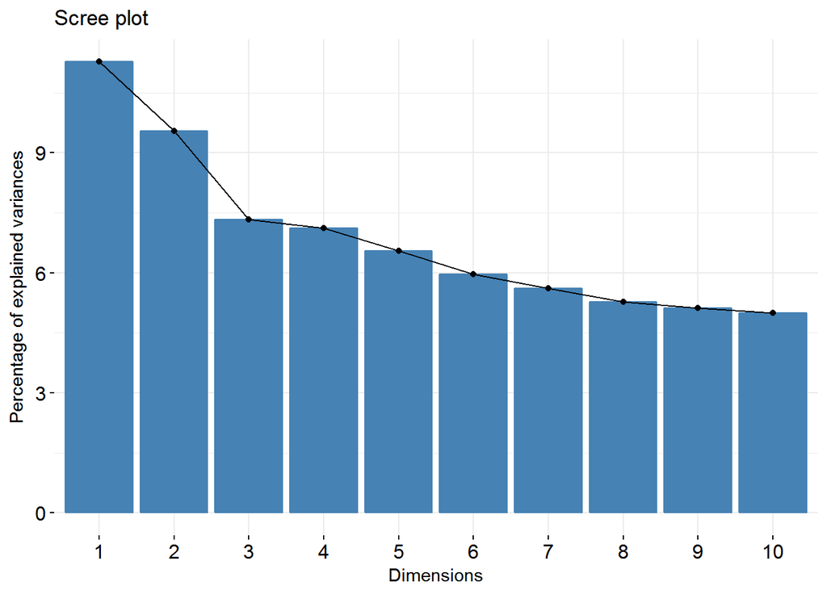

```r
# scree plot
fviz_screeplot(mca)
```

**BIPLOT OF VARIABLES/CATEGORIES INCLUDING INDIVIDUALS**

This biplot shows a global patter within the data. Rows, i.e. individuals, are shown by blue points and number, whereas the columns (variable categories) by red triangles. The distance between any row points or column points gives a measure of their similarity or dissimilarity. Thus row/column points with similar profile are closed on the factor map.

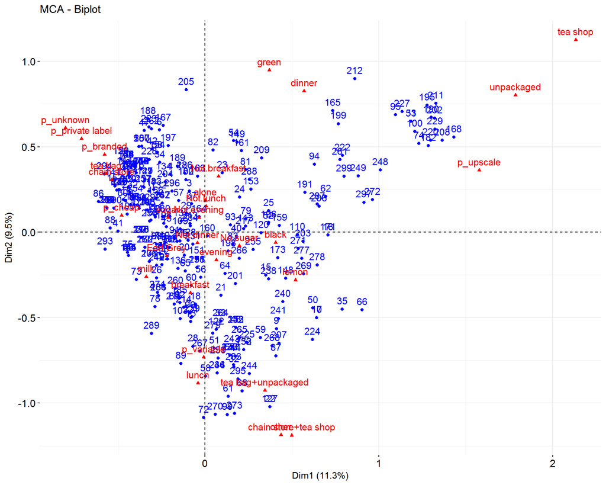

```r
library(factoextra)
fviz_mca_biplot(mca)
```

**BIPLOT OF VARIABLES/ CATEGORIES**

Here I show the biplot of variables and their categories. We can say that the first dimension or component opposes for example the categories “tea shop” with the category “chain store”, “unpackaged” with the “tea bag”, “p_upscale” with the categories “p_unknown”, “p_private label”, “p_branded” and “p-cheap”. Thus it seems that the first component opposes at least sum luxury features with those of the more regular or ordinary features.

The second component distinguishes for example the categories “breakfast” with “Not breakfast”, “alone” with “lemon” and “milk”, “lunch” with “not lunch” and the category “green” with categories “Earl grey” and “black”. Thus it seems that second component opposes some features of timing and flavour.

But it is important to note there are not so powerful (varianle/category) distinctions in the data as a whole. This was also apparent when exploring the eigenvalues. The first and the second dimension didn’t stand out considering the other dimensions. I think that those variables with clear categories distinct the most. For example the variables “how” and “when” and their categories of “both”, i.e. “chain store+tea shop” and “tea bag+unpackages” cause some problems in terms of the clear differences.

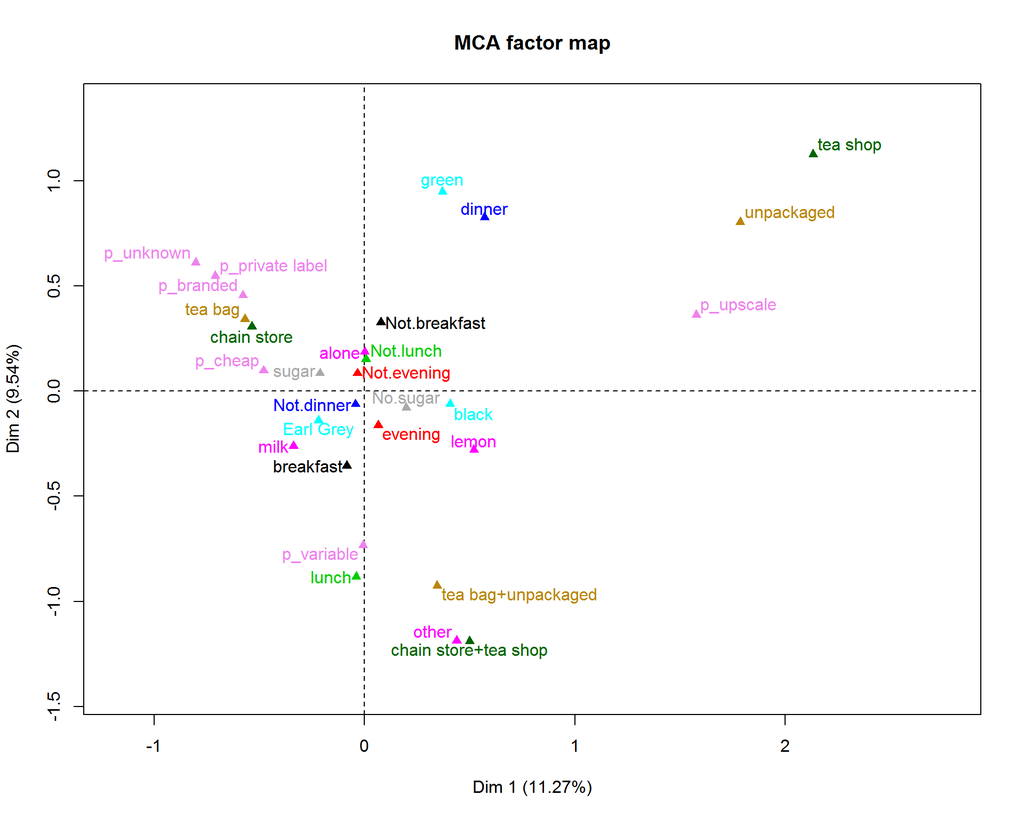

```r
plot(mca, invisible = c("ind"), habillage = "quali")
```

**VARIABLES CATEGORIES**

The function “get_mca_var” is used to extract the results for variable categories. It returns a list containing the coordinates, the cos2 and the contribution of variable categories.

The plot below attempts to show the (squred) correlations between variables and principal dimensions. it is not so clear which variables are correlated with the first dimension and which are with second. My interpretation is that the variables “where”, “how” and “price” could correlate with the first dimension while the other variables may correlate more with the second dimensions.

```r
var <- get_mca_var(mca)
var # MCA results for variables
```

```
## Multiple Correspondence Analysis Results for variables
##  ===================================================
##   Name       Description
## 1 "$coord"   "Coordinates for categories"
## 2 "$cos2"    "Cos2 for categories"
## 3 "$contrib" "contributions of categories"
```

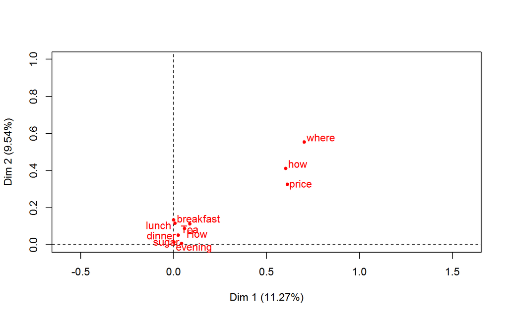

```r
plot(mca, choix = "var")
```

**COORDINATES OF VARIABLES CATEGORIES**

Hmmm.. This is actually the same biplot as before but with the different function. I’ll keep it here to recall the alternatives. But I also printed all of the coordinates to take a numerical look at the variable positioning.

```r
library(factoextra)
table_coord <- (round(var$coord, 2))
table_coord
```

```
##                      Dim 1 Dim 2 Dim 3 Dim 4 Dim 5
## breakfast            -0.08 -0.35  0.37  0.36 -0.01
## Not.breakfast         0.08  0.33 -0.34 -0.34  0.01
## evening               0.06 -0.16 -0.61  0.34 -0.17
## Not.evening          -0.03  0.08  0.32 -0.18  0.09
## lunch                -0.04 -0.88 -0.79  0.72 -0.75
## Not.lunch             0.01  0.15  0.14 -0.12  0.13
## dinner                0.57  0.83 -0.34 -1.95  1.29
## Not.dinner           -0.04 -0.06  0.03  0.15 -0.10
## black                 0.41 -0.06  1.06  0.40  0.00
## Earl Grey            -0.22 -0.14 -0.40 -0.03  0.16
## green                 0.37  0.95 -0.02 -0.69 -0.94
## alone                 0.00  0.19 -0.11 -0.24 -0.42
## lemon                 0.52 -0.28 -0.86  0.38  1.07
## milk                 -0.34 -0.26  0.50  0.83  0.48
## other                 0.44 -1.19  2.10 -1.93  1.85
## No.sugar              0.20 -0.08  0.48 -0.13 -0.45
## sugar                -0.21  0.08 -0.52  0.14  0.48
## tea bag              -0.57  0.34  0.10  0.05  0.12
## tea bag+unpackaged    0.34 -0.93 -0.12 -0.43 -0.12
## unpackaged            1.79  0.80 -0.16  0.89 -0.28
## chain store          -0.54  0.31  0.05  0.05 -0.16
## chain store+tea shop  0.50 -1.19  0.01 -0.28  0.32
## tea shop              2.13  1.13 -0.35  0.45  0.18
## p_branded            -0.58  0.46  0.02 -0.19 -0.14
## p_cheap              -0.48  0.10  0.46  1.93  0.19
## p_private label      -0.71  0.55  0.15  0.42  0.05
## p_unknown            -0.80  0.61  0.27  0.99  2.09
## p_upscale             1.58  0.36  0.16  0.17  0.26
## p_variable           -0.01 -0.73 -0.18 -0.23 -0.25
```

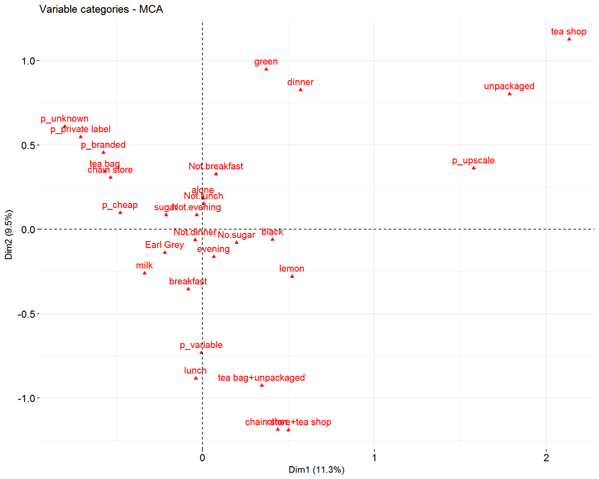

```r
fviz_mca_var(mca)
```

**CONTRIBUTION OF VARIABLES TO FIRST DIMENSION**

Below you can see the barplot of contributors to the first dimension. If the contribution of variable categories were uniform, the expected value would be 1/ number of categories = 1/29 = 3.4%. The red dashed line on the graph below actually indicates this expected average contribution. Additionally for a given dimension, any category with a contribution larger than the dashed line could be considerer as important in contributing to that dimension.

Thus we can see that the categories “tea shop”, “p_upscale”, “unpackaged”, “chain store”, “tea bag” and “p_branded” are the most important in terms of the first dimension. Next we can take a look at the second dimension. This is somewhat consistent with my initial interpretation earlier.

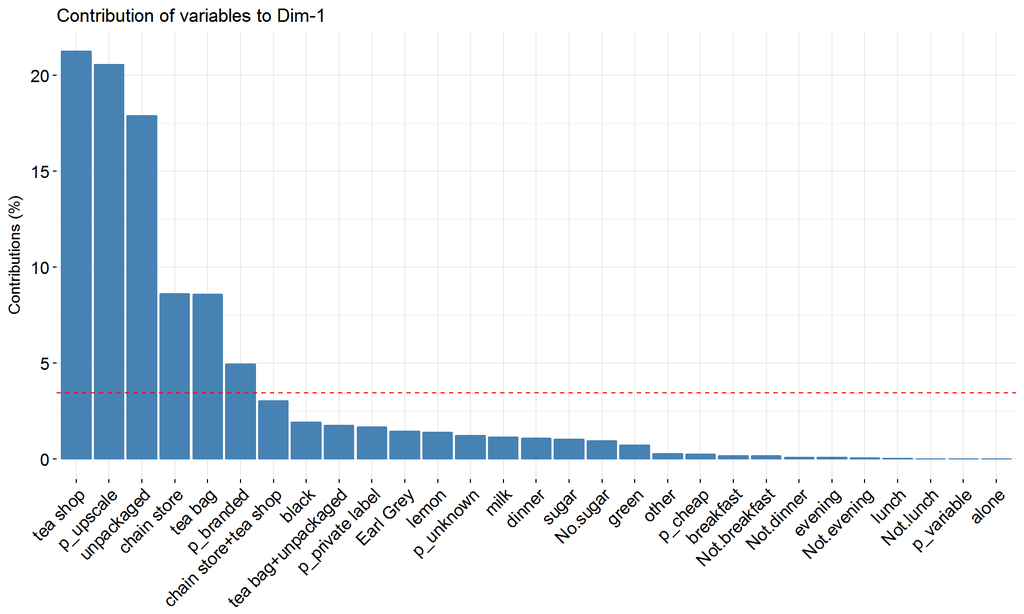

```r
library(factoextra)

# Contributions of variables on first dimension
fviz_contrib(mca, choice = "var", axes = 1)
```

**CONTRIBUTION OF VARIABLES TO SECOND DIMENSION**

From the plot of second dimension we can see that the most important contributors are “chain store+tea shop”, “tea bag+unpackaged”, “p_variable”, “tea shop (again)”, “lunch” and “green”. Here it is more obvious that the second dimension captures the kind of categories which are “unclear”. In other words, there are categories with multiple options (e.g. by tea from the chain store or tea shop), and the category (p_variable) which indicates that the price preferencies varies (e.g. sometimes cheapest, sometimes luxury, etc.).

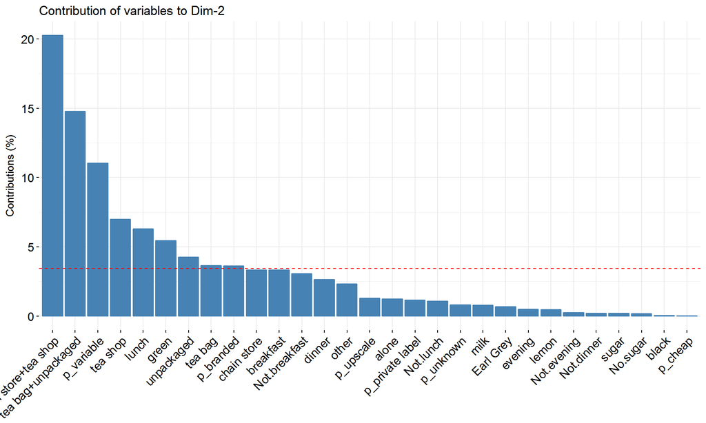

```r
# Contributions of rows on second dimension
fviz_contrib(mca, choice = "var", axes = 2)
```

**TOTAL CONTRIBUTION OF VARIABLES TO FIRST AND SECOND DIMENSIONS**

This is certainly very consistent with the first and second plot but we can print a biplot containing the contributions.

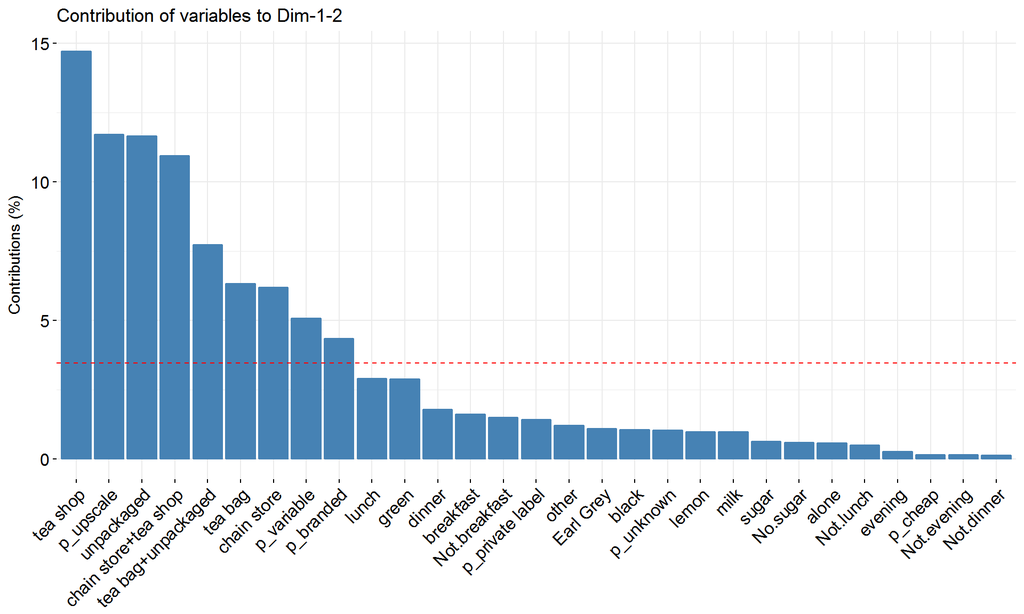

```r
# Total contribution on both dimensions
fviz_contrib(mca, choice = "var", axes = 1:2)
```

**BIPLOT OF TOTAL CONTRIBUTION**

This is nice and much more informative than the earlier biplots. Now I think I have to stop the exploring even if here would be a lot of interesting functions and ways to go further on this analysis. However, I don’t think the additional attempts of dimension reduction would generate any new information or change on the results as seen this far.

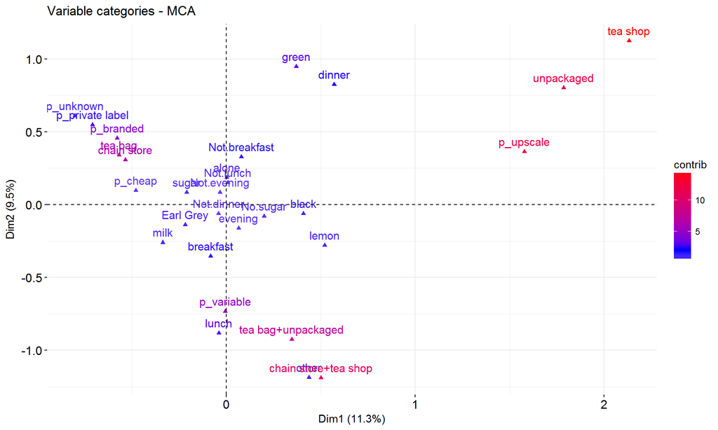

```r
library(factoextra)
fviz_mca_var(mca, col.var = "contrib") + scale_color_gradient2(low="white", mid="blue", high="red", midpoint=2)
```